# AS.FINAL

Brendan Chua

11/21/2020

# 1. Explanation of your data source (where you got it, why it is interesting, etc.)

Was browsing through research articles on a research platform called ‘Frontier’ where researchers post their results and findings. I stumbled across a research study called “Effect of Long-Term Music Training on Emotion Perception From Drumming Improvisation” which was conducted by researchers from the UK and Italy. They collected the data and posted the dataset to figshare, a platform for sharing dataset. I downloaded the Emotion dataset from figshare. Though the dataset is meant for music psychology research, I decided to use it for this project as a ‘switch’ from other musical projects I did for the other courses and I thought getting to know a little bit of music psychology is pretty fun too. I find this dataset interesting because instead of doing some work that deals specifically just on music, this dataset gave me a chance to find out the relationship between drummers expressions and happiness. Also, as a musician myself, though not a drummer, getting to know how drummers express their feelings helps me better understand drummers overall.

# 2. Questions/hypotheses

Q1) Is drummer expressiveness dependent on happiness?

Null: Drummer expressiveness is not dependent on happiness

Alternative: Drummer expressiveness is dependent on happiness

Q2) Is perceived expressiveness dependent on drummer expressiveness when combined with other factors?

Null: Perceived expressiveness is not dependent on drummer expressiveness when combined with other factors

Alternative: Perceived expressiveness is dependent on drummer expressiveness when combined with other factors

# 3. The analyses used

Linear Model (Q1)

Bayesian Linear Model

Bayesian Logistic Regression

Linear Model with multiple factors (Q2)

# 4. Results and an interpretation of those results

Results and Interpretation Commented under each model

# 5. Why the results matter

The results matter because that gave me more insights into how musicians, especially drummers in this case, express their feelings. The findings are pretty interesting in my opinion. The results of this assignment also gave me the opportunity to pay more attention to how drummers express their feelings. If next time I were to have a jam session with drummers, I will take note of the music genre, their gender, complexity of the song, tempo, and the drummer style, and pay more attention towards the level of expressiveness of the drummer. That in the long run, would help me better understand drummers overall.

```r
library(readr)
Emotion_Data <- read_csv("~/Desktop/Dataset Music Emotion Perception.csv")
summary(Emotion_Data)
```

```
##     GROUP                 ID           GENDER               AGE
##  Length:4608        Min.   : 1.00   Length:4608        Min.   :20.00
##  Class :character   1st Qu.:12.75   Class :character   1st Qu.:24.00
##  Mode  :character   Median :24.50   Mode  :character   Median :27.00
##                     Mean   :24.50                      Mean   :28.90
##                     3rd Qu.:36.25                      3rd Qu.:32.25
##                     Max.   :48.00                      Max.   :44.00
##  INSTRUMENT_PLAYED  YEARS_MUSIC_TRAINING MUSICAL_GENRE       COMPLEXITY
##  Length:4608        Min.   : 0.000       Length:4608        Length:4608
##  Class :character   1st Qu.: 0.000       Class :character   Class :character
##  Mode  :character   Median : 8.500       Mode  :character   Mode  :character
##                     Mean   : 9.958
##                     3rd Qu.:16.500
##                     Max.   :39.000
##     TEMPO           DRUMMER_EXPRESSIVENESS DRUMMER_STYLE
##  Length:4608        Length:4608            Length:4608
##  Class :character   Class :character       Class :character
##  Mode  :character   Mode  :character       Mode  :character
##
##
##
##    MODALITY         perceived_expressiveness emotional_valence    neutral
##  Length:4608        Min.   :1.000            Min.   :0.0000    Min.   :0.0000
##  Class :character   1st Qu.:3.000            1st Qu.:0.0000    1st Qu.:0.0000
##  Mode  :character   Median :5.000            Median :1.0000    Median :0.0000
##                     Mean   :4.439            Mean   :0.7001    Mean   :0.3748
##                     3rd Qu.:6.000            3rd Qu.:1.0000    3rd Qu.:1.0000
##                     Max.   :7.000            Max.   :1.0000    Max.   :1.0000
##    happiness        sadness           anger              fear
##  Min.   :0.000   Min.   :0.0000   Min.   :0.00000   Min.   :0.00000
##  1st Qu.:0.000   1st Qu.:0.0000   1st Qu.:0.00000   1st Qu.:0.00000
##  Median :0.000   Median :0.0000   Median :0.00000   Median :0.00000
##  Mean   :0.204   Mean   :0.1246   Mean   :0.09505   Mean   :0.04015
##  3rd Qu.:0.000   3rd Qu.:0.0000   3rd Qu.:0.00000   3rd Qu.:0.00000
##  Max.   :1.000   Max.   :1.0000   Max.   :1.00000   Max.   :1.00000
##     disgust           surprise
##  Min.   :0.00000   Min.   :0.0000
##  1st Qu.:0.00000   1st Qu.:0.0000
##  Median :0.00000   Median :0.0000
##  Mean   :0.05512   Mean   :0.1063
##  3rd Qu.:0.00000   3rd Qu.:0.0000
##  Max.   :1.00000   Max.   :1.0000
```

```r
unique(Emotion_Data$GROUP)
```

```
## [1] "non-musician"         "drummer"              "non-drummer musician"
```

```r
unique(Emotion_Data$INSTRUMENT_PLAYED)
```

```
##  [1] "none"            "drums"           "piano"           "bass"
##  [5] "piano_accordion" "piano_violin"    "violin"          "guitar"
##  [9] "saxophone"       "flute"
```

```r
unique(Emotion_Data$MUSICAL_GENRE)
```

```
## [1] "jazz"        "heavy_metal"
```

```r
unique(Emotion_Data$COMPLEXITY)
```

```
## [1] "complex" "simple"
```

```r
unique(Emotion_Data$GENDER)
```

```
## [1] "female" "male"
```

```r
unique(Emotion_Data$TEMPO)
```

```
## [1] "slow" "fast"
```

```r
unique(Emotion_Data$DRUMMER_EXPRESSIVENESS)
```

```
## [1] "expressive" "neutral"
```

```r
unique(Emotion_Data$DRUMMER_STYLE)
```

```
## [1] "open"  "close"
```

```r
unique(Emotion_Data$MODALITY)
```

```
## [1] "audio"      "audiovideo" "video"
```

```r
str(Emotion_Data)
```

```
## tibble [4,608 × 21] (S3: spec_tbl_df/tbl_df/tbl/data.frame)
##  $ GROUP                   : chr [1:4608] "non-musician" "non-musician" "non-musician" "non-musician" ...
##  $ ID                      : num [1:4608] 1 1 1 1 1 1 1 1 1 1 ...
##  $ GENDER                  : chr [1:4608] "female" "female" "female" "female" ...
##  $ AGE                     : num [1:4608] 24 24 24 24 24 24 24 24 24 24 ...
##  $ INSTRUMENT_PLAYED       : chr [1:4608] "none" "none" "none" "none" ...
##  $ YEARS_MUSIC_TRAINING    : num [1:4608] 0 0 0 0 0 0 0 0 0 0 ...
##  $ MUSICAL_GENRE           : chr [1:4608] "jazz" "jazz" "jazz" "jazz" ...
##  $ COMPLEXITY              : chr [1:4608] "complex" "complex" "complex" "complex" ...
##  $ TEMPO                   : chr [1:4608] "slow" "slow" "slow" "slow" ...
##  $ DRUMMER_EXPRESSIVENESS  : chr [1:4608] "expressive" "expressive" "expressive" "expressive" ...
##  $ DRUMMER_STYLE           : chr [1:4608] "open" "open" "open" "close" ...
##  $ MODALITY                : chr [1:4608] "audio" "audiovideo" "video" "audio" ...
##  $ perceived_expressiveness: num [1:4608] 2 4 4 2 3 3 3 4 3 2 ...
##  $ emotional_valence       : num [1:4608] 0 1 0 0 0 1 0 0 0 0 ...
##  $ neutral                 : num [1:4608] 0 1 0 0 1 1 0 1 0 0 ...
##  $ happiness               : num [1:4608] 0 0 0 0 0 0 0 0 0 0 ...
##  $ sadness                 : num [1:4608] 1 0 1 1 0 0 0 0 1 1 ...
##  $ anger                   : num [1:4608] 0 0 0 0 0 0 0 0 0 0 ...
##  $ fear                    : num [1:4608] 0 0 0 0 0 0 1 0 0 0 ...
##  $ disgust                 : num [1:4608] 0 0 0 0 0 0 0 0 0 0 ...
##  $ surprise                : num [1:4608] 0 0 0 0 0 0 0 0 0 0 ...
##  - attr(*, "spec")=
##   .. cols(
##   ..   GROUP = col_character(),
##   ..   ID = col_double(),
##   ..   GENDER = col_character(),
##   ..   AGE = col_double(),
##   ..   INSTRUMENT_PLAYED = col_character(),
##   ..   YEARS_MUSIC_TRAINING = col_double(),
##   ..   MUSICAL_GENRE = col_character(),
##   ..   COMPLEXITY = col_character(),
##   ..   TEMPO = col_character(),
##   ..   DRUMMER_EXPRESSIVENESS = col_character(),
##   ..   DRUMMER_STYLE = col_character(),
##   ..   MODALITY = col_character(),
##   ..   perceived_expressiveness = col_double(),
##   ..   emotional_valence = col_double(),
##   ..   neutral = col_double(),
##   ..   happiness = col_double(),
##   ..   sadness = col_double(),
##   ..   anger = col_double(),
##   ..   fear = col_double(),
##   ..   disgust = col_double(),
##   ..   surprise = col_double()
##   .. )
```

# Linear Model

First, I need to change my drummer expressivess from a factor to numeric

```r
library(dplyr)
Emotion_Data_2 <- Emotion_Data %>%
  mutate(`DRUMMER_EXPRESSIVENESS` = replace(`DRUMMER_EXPRESSIVENESS`, `DRUMMER_EXPRESSIVENESS` == 'expressive', '1'))%>%
  mutate(`DRUMMER_EXPRESSIVENESS` = replace(`DRUMMER_EXPRESSIVENESS`, `DRUMMER_EXPRESSIVENESS` == 'neutral', '0'))
```

Running lm model

```r
Mod_int <- lm(DRUMMER_EXPRESSIVENESS ~ happiness, data = Emotion_Data_2)

summary(Mod_int)
```

```
##
## Call:
## lm(formula = DRUMMER_EXPRESSIVENESS ~ happiness, data = Emotion_Data_2)
##
## Residuals:
##      Min       1Q   Median       3Q      Max
## -0.58404 -0.47846 -0.03125  0.52154  0.52154
##
## Coefficients:
##             Estimate Std. Error t value Pr(>|t|)
## (Intercept) 0.478462   0.008228  58.154  < 2e-16 ***
## happiness   0.105580   0.018216   5.796 7.25e-09 ***
## ---
## Signif. codes:  0 '***' 0.001 '**' 0.01 '*' 0.05 '.' 0.1 ' ' 1
##
## Residual standard error: 0.4983 on 4606 degrees of freedom
## Multiple R-squared:  0.00724,    Adjusted R-squared:  0.007025
## F-statistic: 33.59 on 1 and 4606 DF,  p-value: 7.25e-09
```

```r
coef(Mod_int)
```

```
## (Intercept)   happiness
##   0.4784624   0.1055802
```

Results shows that they are significantly correlated. So for that reason, I can reject the NULL.

# Bayesian Linear Model

```r
library(rstanarm)
blm = stan_lm(DRUMMER_EXPRESSIVENESS ~ happiness ,
              data = Emotion_Data_2,
              prior = R2(.1, "mean"), seed = 888888, chains = 5,
              cores = (parallel::detectCores() - 1),
              iter = 8888)
```

```r
summary(blm)
```

```
##
## Model Info:
##  function:     stan_lm
##  family:       gaussian [identity]
##  formula:      DRUMMER_EXPRESSIVENESS ~ happiness
##  algorithm:    sampling
##  sample:       22220 (posterior sample size)
##  priors:       see help('prior_summary')
##  observations: 4608
##  predictors:   2
##
## Estimates:
##                 mean   sd   10%   50%   90%
## (Intercept)   0.5    0.0  0.5   0.5   0.5
## happiness     0.1    0.0  0.1   0.1   0.1
## sigma         0.5    0.0  0.5   0.5   0.5
## log-fit_ratio 0.0    0.0  0.0   0.0   0.1
## R2            0.0    0.0  0.0   0.0   0.0
##
## Fit Diagnostics:
##            mean   sd   10%   50%   90%
## mean_PPD 0.5    0.0  0.5   0.5   0.5
##
## The mean_ppd is the sample average posterior predictive distribution of the outcome variable (for details see help('summary.stanreg')).
##
## MCMC diagnostics
##               mcse Rhat n_eff
## (Intercept)   0.0  1.0  10807
## happiness     0.0  1.0   9216
## sigma         0.0  1.0  16216
## log-fit_ratio 0.0  1.0  10443
## R2            0.0  1.0   9291
## mean_PPD      0.0  1.0  16969
## log-posterior 0.0  1.0   8393
##
## For each parameter, mcse is Monte Carlo standard error, n_eff is a crude measure of effective sample size, and Rhat is the potential scale reduction factor on split chains (at convergence Rhat=1).
```

```r
posterior_interval(blm, prob = .95, pars = "happiness")
```

```
##                 2.5%     97.5%
## happiness 0.06979058 0.1405223
```

95% of the true parameter fall between this range - 0.0698 to 0.14.

Plotting to see how it looks

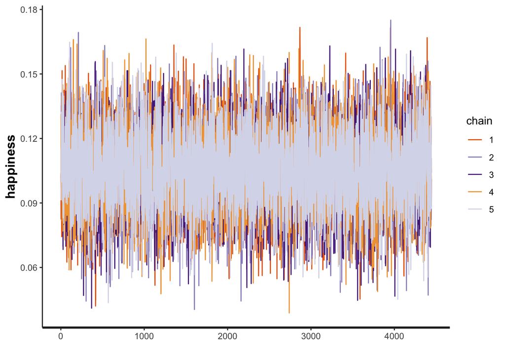

```r
rstan::stan_trace(blm, pars = "happiness")
```

# Bayesian Logistic regression

```r
library(ggplot2)

Emotion_Data_2<- Emotion_Data
```

```r
logTest = glm(as.factor(DRUMMER_EXPRESSIVENESS) ~ happiness,
              data = Emotion_Data_2[sample(1:nrow(Emotion_Data_2), replace = FALSE), ],
              family = binomial)

summary(logTest)
```

```
##
## Call:
## glm(formula = as.factor(DRUMMER_EXPRESSIVENESS) ~ happiness,
##     family = binomial, data = Emotion_Data_2[sample(1:nrow(Emotion_Data_2),
##         replace = FALSE), ])
##
## Deviance Residuals:
##      Min        1Q    Median        3Q       Max
## -1.21423  -1.21423   0.05197   1.14103   1.32452
##
## Coefficients:
##             Estimate Std. Error z value Pr(>|z|)
## (Intercept)  0.08620    0.03305   2.608  0.00911 **
## happiness   -0.42559    0.07397  -5.754 8.73e-09 ***
## ---
## Signif. codes:  0 '***' 0.001 '**' 0.01 '*' 0.05 '.' 0.1 ' ' 1
##
## (Dispersion parameter for binomial family taken to be 1)
##
##     Null deviance: 6388.0  on 4607  degrees of freedom
## Residual deviance: 6354.6  on 4606  degrees of freedom
## AIC: 6358.6
##
## Number of Fisher Scoring iterations: 3
```

```r
bLog = stan_glm(as.factor(DRUMMER_EXPRESSIVENESS) ~ happiness, data = Emotion_Data_2, family = binomial,
              prior = student_t(df = 7, location = 0, scale = 2.5),
              prior_intercept = student_t(df = 7, location = 0, scale = 2.5),
              seed = 888888, chains = 5,
              cores = (parallel::detectCores() - 1),
              iter = 5000)

summary(bLog)
```

```
##
## Model Info:
##  function:     stan_glm
##  family:       binomial [logit]
##  formula:      as.factor(DRUMMER_EXPRESSIVENESS) ~ happiness
##  algorithm:    sampling
##  sample:       12500 (posterior sample size)
##  priors:       see help('prior_summary')
##  observations: 4608
##  predictors:   2
##
## Estimates:
##               mean   sd   10%   50%   90%
## (Intercept)  0.1    0.0  0.0   0.1   0.1
## happiness   -0.4    0.1 -0.5  -0.4  -0.3
##
## Fit Diagnostics:
##            mean   sd   10%   50%   90%
## mean_PPD 0.5    0.0  0.5   0.5   0.5
##
## The mean_ppd is the sample average posterior predictive distribution of the outcome variable (for details see help('summary.stanreg')).
##
## MCMC diagnostics
##               mcse Rhat n_eff
## (Intercept)   0.0  1.0   8355
## happiness     0.0  1.0   8254
## mean_PPD      0.0  1.0  10387
## log-posterior 0.0  1.0   4960
##
## For each parameter, mcse is Monte Carlo standard error, n_eff is a crude measure of effective sample size, and Rhat is the potential scale reduction factor on split chains (at convergence Rhat=1).
```

```r
exp(-0.4)
```

```
## [1] 0.67032
```

# Second lm model: perceived expressiveness on drummer expressiveness (With multiple factors)

```r
Emotion_Data_3 <- Emotion_Data

lm2 <-lm(perceived_expressiveness ~ DRUMMER_EXPRESSIVENESS + COMPLEXITY + DRUMMER_STYLE + MUSICAL_GENRE + TEMPO + GENDER,
         data = Emotion_Data_3)
summary(lm2)
```

```
##
## Call:
## lm(formula = perceived_expressiveness ~ DRUMMER_EXPRESSIVENESS +
##     COMPLEXITY + DRUMMER_STYLE + MUSICAL_GENRE + TEMPO + GENDER,
##     data = Emotion_Data_3)
##
## Residuals:
##     Min      1Q  Median      3Q     Max
## -4.6519 -1.1831  0.1597  1.2843  3.7936
##
## Coefficients:
##                               Estimate Std. Error t value Pr(>|t|)
## (Intercept)                    5.65970    0.06429  88.035  < 2e-16 ***
## DRUMMER_EXPRESSIVENESSneutral -0.70139    0.04830 -14.522  < 2e-16 ***
## COMPLEXITYsimple              -0.04253    0.04830  -0.881    0.379
## DRUMMER_STYLEopen              0.03472    0.04830   0.719    0.472
## MUSICAL_GENREjazz             -0.76736    0.04830 -15.888  < 2e-16 ***
## TEMPOslow                     -0.38542    0.04830  -7.980 1.84e-15 ***
## GENDERmale                    -0.55663    0.04834 -11.515  < 2e-16 ***
## ---
## Signif. codes:  0 '***' 0.001 '**' 0.01 '*' 0.05 '.' 0.1 ' ' 1
##
## Residual standard error: 1.639 on 4601 degrees of freedom
## Multiple R-squared:  0.1256, Adjusted R-squared:  0.1245
## F-statistic: 110.1 on 6 and 4601 DF,  p-value: < 2.2e-16
```

```r
library(effects)
```

```
## NOTE: MUSICAL_GENRE:TEMPO does not appear in the model
```

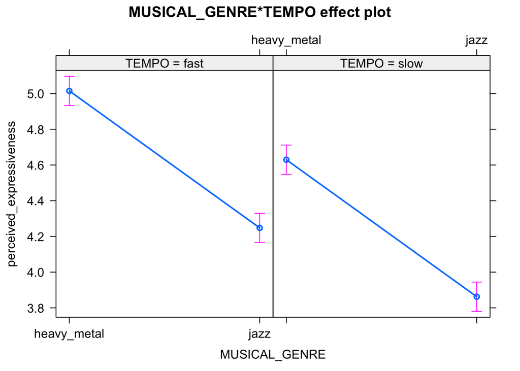

```r
plot(effect("MUSICAL_GENRE * TEMPO",lm2))
```

```
## NOTE: COMPLEXITY:DRUMMER_STYLE does not appear in the model
```

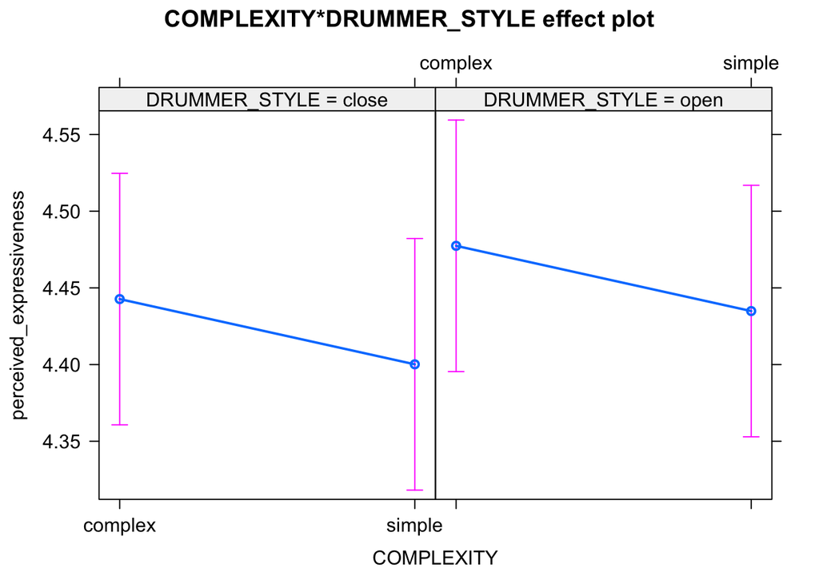

```r
plot(effect("COMPLEXITY * DRUMMER_STYLE",lm2))
```

```
## NOTE: DRUMMER_EXPRESSIVENESS:COMPLEXITY does not appear in the model
```

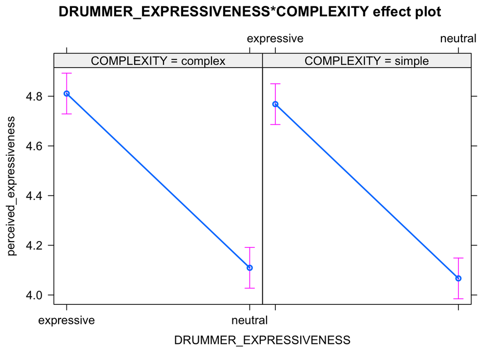

```r
plot(effect("DRUMMER_EXPRESSIVENESS * COMPLEXITY",lm2))
```

```
## NOTE: DRUMMER_EXPRESSIVENESS:MUSICAL_GENRE does not appear in the model
```

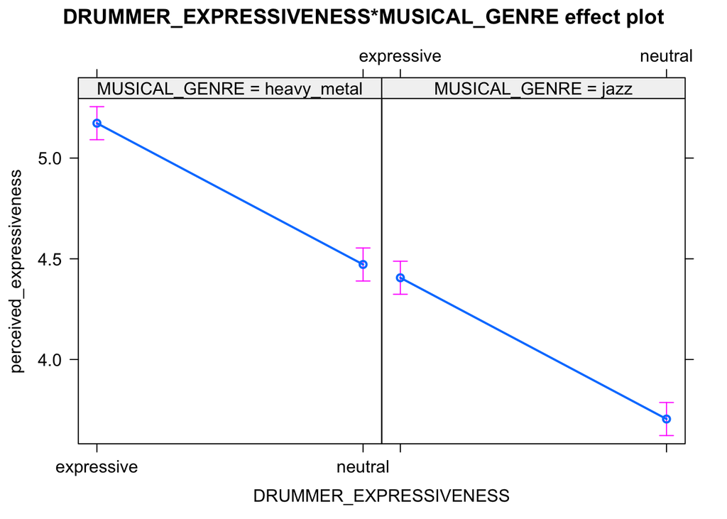

```r
plot(effect("DRUMMER_EXPRESSIVENESS * MUSICAL_GENRE",lm2))
```

```
## NOTE: DRUMMER_EXPRESSIVENESS:DRUMMER_STYLE does not appear in the model
```

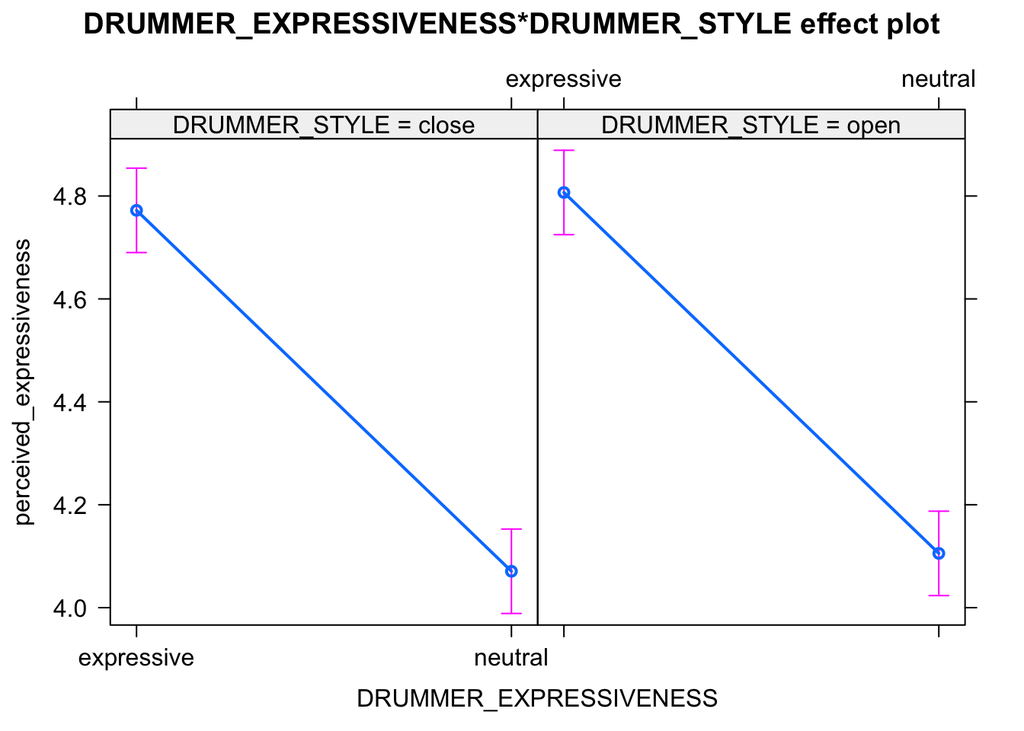

```r
plot(effect("DRUMMER_EXPRESSIVENESS * DRUMMER_STYLE",lm2))
```

```
## NOTE: DRUMMER_EXPRESSIVENESS:GENDER does not appear in the model
```

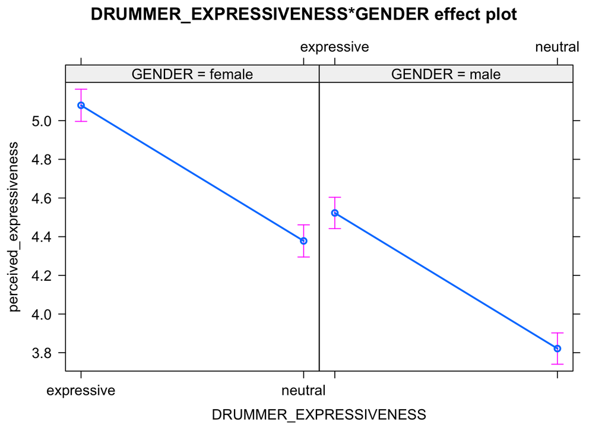

```r
plot(effect("DRUMMER_EXPRESSIVENESS * GENDER",lm2))
```

```
## NOTE: DRUMMER_EXPRESSIVENESS:TEMPO does not appear in the model
```

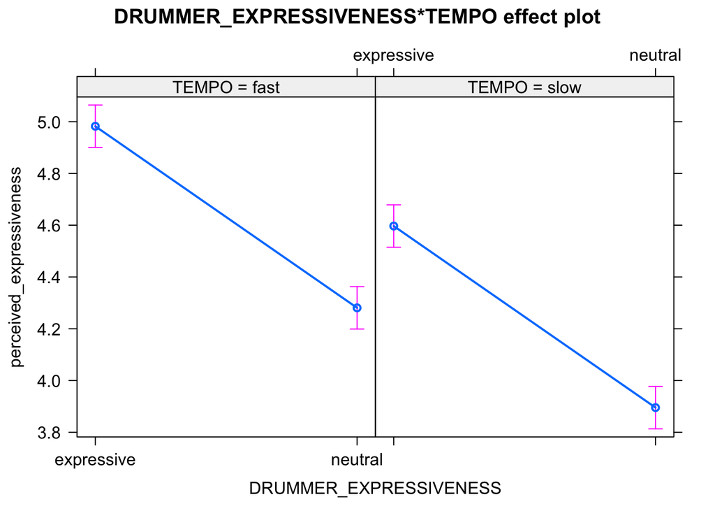

```r
plot(effect("DRUMMER_EXPRESSIVENESS * TEMPO",lm2))
```

SO based on that, I can reject the NULL hypothesis